# STATS503_HW8_Shenyi Tang

#### Question 1

**ISLP chapter 9 exercise #2**

**We have seen that in $p = 2$ dimensions, a linear decision boundary takes the form $\beta_0 +\beta_1X_1 +\beta_2X_2 = 0$. We now investigate a non-linear decision boundary.**

**(a) Sketch the curve** $$(1+X_1)^2+(2-X_2)^2=4$$

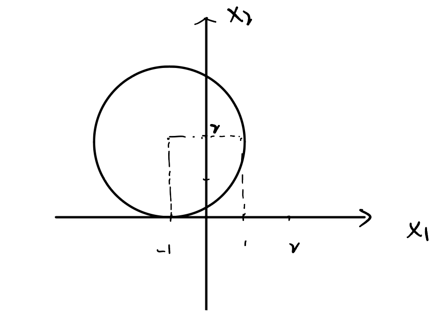

**(b) On your sketch, indicate the set of points for which** $$(1+X_1)^2+(2-X_2)^2>4$$ **as well as the set of points which** $$(1+X_1)^2+(2-X_2)^2\le4$$

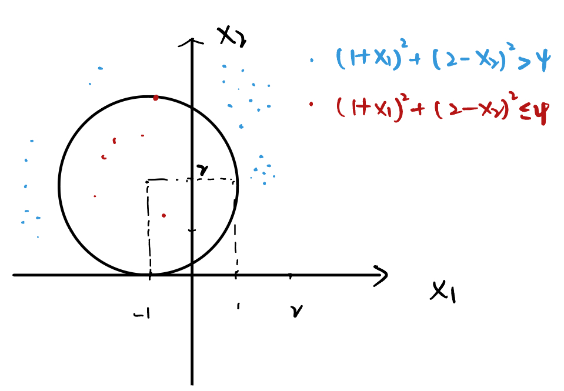

**(c)Suppose that a classifier assigns an observation to the blue class if** $$(1+X_1)^2+(2-X_2)^2>4$$ **and to the red class otherwise. To what class is the observation $(0,0)$ classified? $(-1,1)?$ $(2,2)?$ $(3,8)?$**

- Blue Class: $(0,0),(2,2),(3,8)$
- Red Class: $(-1,1)$

**(d) Argue that while the decision boundary in (c) is not linear in terms of $X_1$ and $X_2$, it is linear in terms of $X_1$, $X_2$, $X_1^2$, $X_2^2$ .**

Expanding the expression of decision boundary: $$(1+X_1)^2+(2-X_2)^2=4 \Rightarrow X_1^2+2X_1+X_2^2-4X_2+1=0$$ which is linear in terms of $X_1$, $X_2$, $X_1^2$, $X_2^2$

#### Question 2

**ISLP chapter 9 exercise #3**

**Here we explore the maximal margin classifier on a toy data set.**

**(a) We are given $n = 7$ observations in $p = 2$ dimensions. For each observation, there is an associated class label. Sketch the observations.**

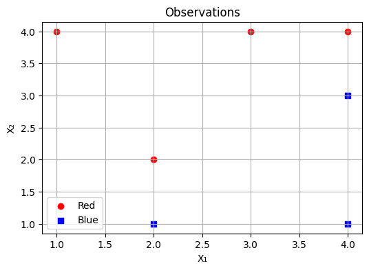

```python
import matplotlib.pyplot as plt

# Data points
red_points = [(3,4), (2,2), (4,4), (1,4)]
blue_points = [(2,1), (4,3), (4,1)]

# Plotting
plt.figure(figsize=(6, 4))
for (x, y) in red_points:
    plt.scatter(x, y, color='red', marker='o', label='Red' if (x,y)==(3,4) else "")
for (x, y) in blue_points:
    plt.scatter(x, y, color='blue', marker='s', label='Blue' if (x,y)==(2,1) else "")

plt.xlabel('X₁')
plt.ylabel('X₂')
plt.title('Observations')
plt.grid(True)
plt.legend()
plt.show()
```

**(b) Sketch the optimal separating hyperplane, and provide the equation for this hyperplane**

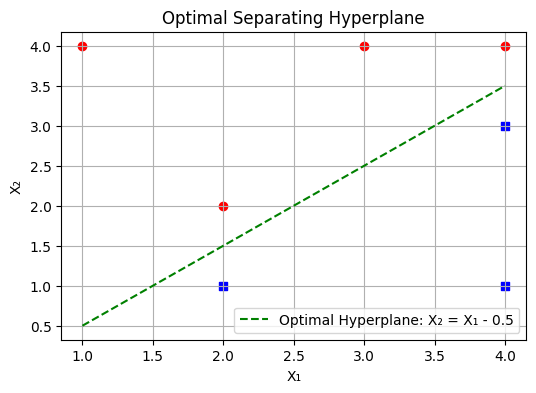

```python
# Plotting the hyperplane
x_vals = [1, 4]
y_vals = [x - 0.5 for x in x_vals]

plt.figure(figsize=(6, 4))
plt.plot(x_vals, y_vals, 'g--', label='Optimal Hyperplane: X₂ = X₁ - 0.5')

# Replot points
for (x, y) in red_points:
    plt.scatter(x, y, color='red', marker='o')
for (x, y) in blue_points:
    plt.scatter(x, y, color='blue', marker='s')

plt.xlabel('X₁')
plt.ylabel('X₂')
plt.title('Optimal Separating Hyperplane')
plt.grid(True)
plt.legend()
plt.show()
```

**(d) On your sketch, indicate the margin for the maximal margin hyperplane.**

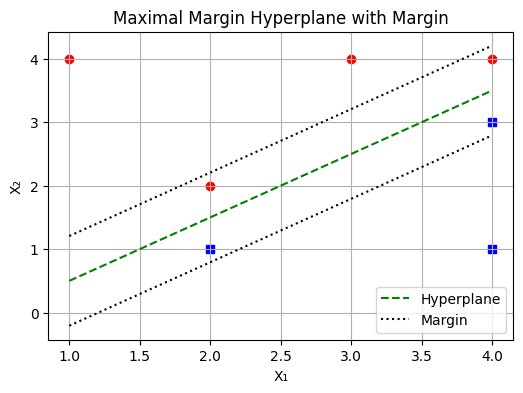

```python
import numpy as np

# Margin lines (parallel to hyperplane)
margin = 1 / np.sqrt(2)  # Distance for margin

# Upper margin line: X₂ = X₁ - 1 + margin*sqrt(2)
y_upper = [x - 0.5 + margin for x in x_vals]

# Lower margin line: X₂ = X₁ - 1 - margin*sqrt(2)
y_lower = [x - 0.5 - margin for x in x_vals]

plt.figure(figsize=(6, 4))
plt.plot(x_vals, y_vals, 'g--', label='Hyperplane')
plt.plot(x_vals, y_upper, 'k:', label='Margin')
plt.plot(x_vals, y_lower, 'k:')

# Replot points
for (x, y) in red_points:
    plt.scatter(x, y, color='red', marker='o')
for (x, y) in blue_points:
    plt.scatter(x, y, color='blue', marker='s')

plt.xlabel('X₁')
plt.ylabel('X₂')
plt.title('Maximal Margin Hyperplane with Margin')
plt.grid(True)
plt.legend()
plt.show()
```

**(e) Indicate the support vectors for the maximal margin classifier.**

- Red: $(2,2), (4,4)$
- Blue: $(2,1), (4,3)$

**(f) Argue that a slight movement of the seventh observation would not affect the maximal margin hyperplane.**

Observation 7 $(4,1)$ is far from the hyperplane and not a support vector. Slight movement won’t affect the margin or hyperplane.

**(g) Sketch a hyperplane that is not the optimal separating hyperplane, and provide the equation for this hyperplane.**

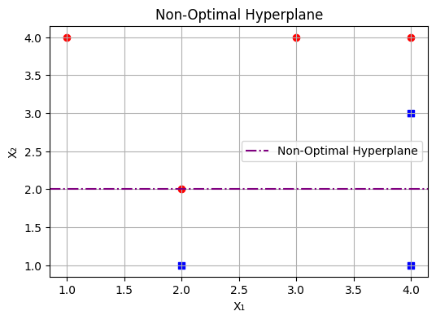

```python
plt.figure(figsize=(6,4))
plt.axhline(y=2, color='purple', linestyle='-.', label='Non-Optimal Hyperplane')

# Replot points
for (x, y) in red_points:
    plt.scatter(x, y, color='red', marker='o')
for (x, y) in blue_points:
    plt.scatter(x, y, color='blue', marker='s')

plt.xlabel('X₁')
plt.ylabel('X₂')
plt.title('Non-Optimal Hyperplane')
plt.grid(True)
plt.legend()
plt.show()
```

**(h) Draw an additional observation on the plot so that the two classes are no longer separable by a hyperplane.**

[figure not shown]

```python
plt.figure(figsize=(6, 4))

x_vals = [1, 4]
y_vals = [x - 1 for x in x_vals]

plt.figure(figsize=(6, 4))
plt.plot(x_vals, y_vals, 'g--', label='Optimal Hyperplane: X₂ = X₁ - 1')
plt.scatter(3, 2.5, color='blue', marker='s', label='New Blue Point')

# Replot original points
for (x, y) in red_points:
    plt.scatter(x, y, color='red', marker='o')
for (x, y) in blue_points:
    plt.scatter(x, y, color='blue', marker='s')

plt.xlabel('X₁')
plt.ylabel('X₂')
plt.title('Non-Separable Classes')
plt.grid(True)
plt.legend()
plt.show()
```

#### Question 3

**For this question, use graph paper, a drawing application, or Python**

**(a) Suppose** $$f(X_1,X_2)=\frac{1}{\sqrt{2}}X_1-\frac{1}{\sqrt{2}}X_2-1$$ **Draw the hyperplane defined by $f (X_1, X_2) = 0$. Indicate the region of possible inputs $x_1$, $x_2$ for which $f (X_1, X_2) > 0$ with a “+” sign. Indicate the region of possible inputs $x_1$, $x_2$ for which $f (X_1, X_2) < 0$ with a “-”sign.**

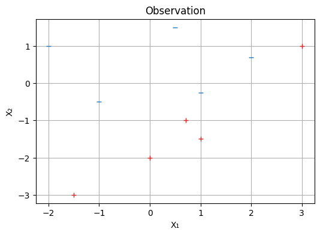

```python
p = [(-1, -0.5), (-2,1), (0.5,1.5), (1,-0.25), (2,0.7)] # f < 0
n = [(-1.5, -3), (0, -2), (1,-1.5), (1/np.sqrt(2), -1), (3,1)] # f > 0

plt.figure(figsize=(6,4))
for (x,y) in n:
    plt.plot(x, y, marker="+", color="C3")
for (x,y) in p:
    plt.plot(x, y, marker="_", color="C0")

plt.xlabel('X₁')
plt.ylabel('X₂')
plt.title("Observation")
plt.grid(True)
plt.show()
```

**(b) Suppose an SVM classifier is fitted to data, resulting in the following decision rule:** $$\hat{y}(x_1,x_2)= \begin{cases} +, & \text{if}f(x_1,x_2)>0, \\ -, & \text{otherwise} \end{cases} $$ **Suppose further that this SVM is associated with a margin of m = $\sqrt{2}$. Draw the margin lines.**

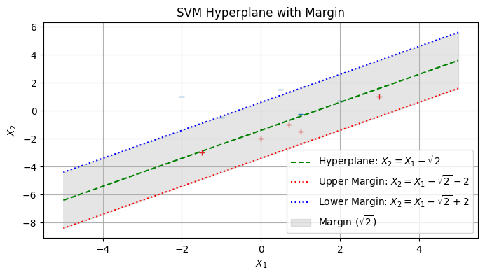

```python
def hyperplane(x1):
    return x1 - np.sqrt(2)

def upper_margin(x1):
    return x1 - np.sqrt(2) - 2

def lower_margin(x1):
    return x1 - np.sqrt(2) + 2

x1 = np.linspace(-5, 5, 100)

p = [(-1, -0.5), (-2,1), (0.5,1.5), (1,-0.25), (2,0.7)] # f < 0
n = [(-1.5, -3), (0, -2), (1,-1.5), (1/np.sqrt(2), -1), (3,1)] # f > 0

hyperplane_x2 = hyperplane(x1)
upper_x2 = upper_margin(x1)
lower_x2 = lower_margin(x1)

plt.figure(figsize=(8,4))
plt.plot(x1, hyperplane_x2, 'g--', label='Hyperplane: $X_2 = X_1 - \sqrt{2}$')
plt.plot(x1, upper_x2, 'r:', label='Upper Margin: $X_2 = X_1 - \sqrt{2} - 2$')
plt.plot(x1, lower_x2, 'b:', label='Lower Margin: $X_2 = X_1 - \sqrt{2} + 2$')

for (x,y) in n:
    plt.plot(x, y, marker="+", color="C3")
for (x,y) in p:
    plt.plot(x, y, marker="_", color="C0")

plt.fill_between(x1, upper_x2, lower_x2, color='gray', alpha=0.2, label=f'Margin ($\sqrt{{2}}$)')

plt.xlabel('$X_1$')
plt.ylabel('$X_2$')
plt.title('SVM Hyperplane with Margin')
plt.grid(True)
plt.legend()
plt.show()
```

**(c) What class label ($+$ or $-$, as defined above) does this SVM predict for the following points: $(1,4)$; $(1,1)$; $(2, -5)$; $(2, -1)$; $(4,2)$?**

- $+$: $(2,-5),(2,-1),(4,2)$
- $-$: $(1,4),(1,1)$

#### Question 4

**This question uses the `crabs.csv` data, with the five body measurements as predictors and `species` as the response. Omit all other variables including `sex`. We will assess error in terms of misclassification rate.**

```python
import pandas as pd
from sklearn.metrics import accuracy_score

crabs = pd.read_csv("crabs.csv", index_col=0)
crabs.head()
y = crabs["sp"]
X = crabs.loc[:, 'FL':'BD']
```

**(a) Fit a linear SVM to the data for a range of values of the C hyperparameter, to predict `species` from the five numerical measurements. Plot the cross-validated estimate of the error as a function of C.**

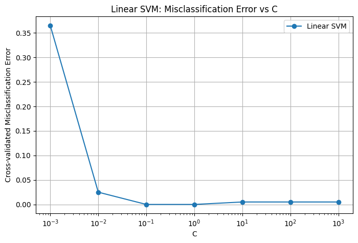

```python
from sklearn.svm import SVC
from sklearn.model_selection import cross_val_score
from sklearn.preprocessing import LabelEncoder
from sklearn.model_selection import train_test_split

# Encode the target labels (species) if necessary
le = LabelEncoder()
y = le.fit_transform(y)

C_values = np.logspace(-3, 3, 7)  # C values from 0.001 to 1000
linear_errors = []

for C in C_values:
    svm = SVC(kernel='linear', C=C)
    error = 1 - cross_val_score(svm, X, y, cv=5, scoring='accuracy').mean()  # Misclassification error
    linear_errors.append(error)

# Plot the error for linear SVM
plt.figure(figsize=(8, 5))
plt.plot(C_values, linear_errors, marker='o', label='Linear SVM')
plt.xscale('log')
plt.xlabel('C')
plt.ylabel('Cross-validated Misclassification Error')
plt.title('Linear SVM: Misclassification Error vs C')
plt.grid(True)
plt.legend()
plt.show()
```

**(b) Now, fit nonlinear SVMs with polynomial kernels. Consider at least three values of degree. For each, plot the cross-validated estimate of the error as a function of C.**

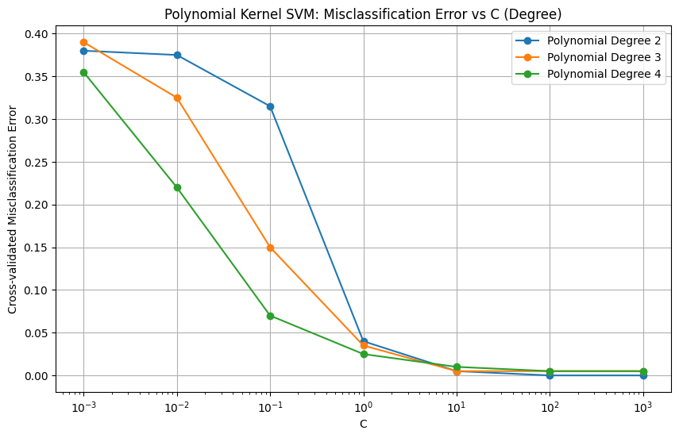

```python
degrees = [2, 3, 4]
C_values = np.logspace(-3, 3, 7)  # C values from 0.001 to 1000
polynomial_errors = {degree: [] for degree in degrees}

for degree in degrees:
    for C in C_values:
        svm = SVC(kernel='poly', C=C, degree=degree)
        error = 1 - cross_val_score(svm, X, y, cv=5, scoring='accuracy').mean()  # Misclassification error
        polynomial_errors[degree].append(error)

plt.figure(figsize=(10, 6))
for degree, errors in polynomial_errors.items():
    plt.plot(C_values, errors, marker='o', label=f'Polynomial Degree {degree}')
plt.xscale('log')
plt.xlabel('C')
plt.ylabel('Cross-validated Misclassification Error')
plt.title('Polynomial Kernel SVM: Misclassification Error vs C (Degree)')
plt.grid(True)
plt.legend()
plt.show()
```

**(c) Finally, fit nonlinear SVMs with radial kernels. Consider at least three values of gamma. For each, plot the cross-validated estimate of the error as a function of C.**

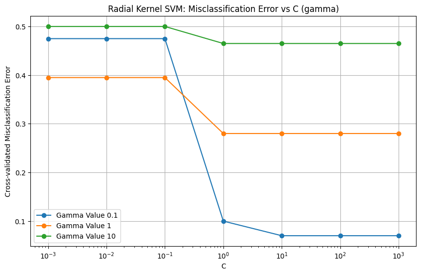

```python
gamma_values = [0.1, 1, 10]  # Gamma values to test
rbf_errors = {gamma: [] for gamma in gamma_values}
C_values = np.logspace(-3, 3, 7)

for gamma in gamma_values:
    for C in C_values:
        svm = SVC(kernel='rbf', gamma=gamma, C=C)
        error = 1 - cross_val_score(svm, X, y, cv=5, scoring='accuracy').mean()
        rbf_errors[gamma].append(error)

plt.figure(figsize=(10, 6))
for gamma, errors in rbf_errors.items():
    plt.plot(C_values, errors, marker='o', label=f'Gamma Value {gamma}')
plt.xscale('log')
plt.xlabel('C')
plt.ylabel('Cross-validated Misclassification Error')
plt.title('Radial Kernel SVM: Misclassification Error vs C (gamma)')
plt.grid(True)
plt.legend()
plt.show()
```